# Risk Factor Analysis

## Outcome Variable

**Outcome Variable:** pers_wast

## Predictor Variables

**Intervention Variable:** birthlen

**Adjustment Set:**

- arm
- sex
- W_mage
- meducyrs
- feducyrs
- vagbrth
- single
- brthmon
- W_parity
- delta_W_mage
- delta_meducyrs
- delta_feducyrs
- delta_vagbrth
- delta_single
- delta_brthmon
- delta_W_parity

## Stratifying Variables

The analysis was stratified on these variable(s):

- agecat
- studyid
- country

## Data Summary

| agecat | studyid | country | birthlen | pers_wast | n_cell | n |
| --- | --- | --- | --- | --- | --- | --- |
| 0-24 months | ki0047075b-MAL-ED | BANGLADESH | >=50 cm | 0 | 26 | 241 |
| 0-24 months | ki0047075b-MAL-ED | BANGLADESH | >=50 cm | 1 | 3 | 241 |
| 0-24 months | ki0047075b-MAL-ED | BANGLADESH | <48 cm | 0 | 120 | 241 |
| 0-24 months | ki0047075b-MAL-ED | BANGLADESH | <48 cm | 1 | 8 | 241 |
| 0-24 months | ki0047075b-MAL-ED | BANGLADESH | [48-50) cm | 0 | 83 | 241 |
| 0-24 months | ki0047075b-MAL-ED | BANGLADESH | [48-50) cm | 1 | 1 | 241 |
| 0-24 months | ki0047075b-MAL-ED | BRAZIL | >=50 cm | 0 | 33 | 180 |
| 0-24 months | ki0047075b-MAL-ED | BRAZIL | >=50 cm | 1 | 0 | 180 |
| 0-24 months | ki0047075b-MAL-ED | BRAZIL | <48 cm | 0 | 72 | 180 |
| 0-24 months | ki0047075b-MAL-ED | BRAZIL | <48 cm | 1 | 1 | 180 |
| 0-24 months | ki0047075b-MAL-ED | BRAZIL | [48-50) cm | 0 | 74 | 180 |
| 0-24 months | ki0047075b-MAL-ED | BRAZIL | [48-50) cm | 1 | 0 | 180 |
| 0-24 months | ki0047075b-MAL-ED | INDIA | >=50 cm | 0 | 23 | 197 |
| 0-24 months | ki0047075b-MAL-ED | INDIA | >=50 cm | 1 | 1 | 197 |
| 0-24 months | ki0047075b-MAL-ED | INDIA | <48 cm | 0 | 97 | 197 |
| 0-24 months | ki0047075b-MAL-ED | INDIA | <48 cm | 1 | 7 | 197 |
| 0-24 months | ki0047075b-MAL-ED | INDIA | [48-50) cm | 0 | 61 | 197 |
| 0-24 months | ki0047075b-MAL-ED | INDIA | [48-50) cm | 1 | 8 | 197 |
| 0-24 months | ki0047075b-MAL-ED | NEPAL | >=50 cm | 0 | 37 | 172 |
| 0-24 months | ki0047075b-MAL-ED | NEPAL | >=50 cm | 1 | 1 | 172 |
| 0-24 months | ki0047075b-MAL-ED | NEPAL | <48 cm | 0 | 68 | 172 |
| 0-24 months | ki0047075b-MAL-ED | NEPAL | <48 cm | 1 | 0 | 172 |
| 0-24 months | ki0047075b-MAL-ED | NEPAL | [48-50) cm | 0 | 66 | 172 |
| 0-24 months | ki0047075b-MAL-ED | NEPAL | [48-50) cm | 1 | 0 | 172 |
| 0-24 months | ki0047075b-MAL-ED | PERU | >=50 cm | 0 | 32 | 271 |
| 0-24 months | ki0047075b-MAL-ED | PERU | >=50 cm | 1 | 0 | 271 |
| 0-24 months | ki0047075b-MAL-ED | PERU | <48 cm | 0 | 135 | 271 |
| 0-24 months | ki0047075b-MAL-ED | PERU | <48 cm | 1 | 1 | 271 |
| 0-24 months | ki0047075b-MAL-ED | PERU | [48-50) cm | 0 | 103 | 271 |
| 0-24 months | ki0047075b-MAL-ED | PERU | [48-50) cm | 1 | 0 | 271 |

[output cut: 444 more lines]

The following strata were considered:

- agecat: 0-24 months, studyid: ki0047075b-MAL-ED, country: BANGLADESH
- agecat: 0-24 months, studyid: ki0047075b-MAL-ED, country: BRAZIL
- agecat: 0-24 months, studyid: ki0047075b-MAL-ED, country: INDIA
- agecat: 0-24 months, studyid: ki0047075b-MAL-ED, country: NEPAL
- agecat: 0-24 months, studyid: ki0047075b-MAL-ED, country: PERU
- agecat: 0-24 months, studyid: ki0047075b-MAL-ED, country: SOUTH AFRICA
- agecat: 0-24 months, studyid: ki0047075b-MAL-ED, country: TANZANIA, UNITED REPUBLIC OF
- agecat: 0-24 months, studyid: ki1000108-CMC-V-BCS-2002, country: INDIA
- agecat: 0-24 months, studyid: ki1000108-IRC, country: INDIA
- agecat: 0-24 months, studyid: ki1000109-EE, country: PAKISTAN
- agecat: 0-24 months, studyid: ki1000109-ResPak, country: PAKISTAN
- agecat: 0-24 months, studyid: ki1000304b-SAS-CompFeed, country: INDIA
- agecat: 0-24 months, studyid: ki1017093-NIH-Birth, country: BANGLADESH
- agecat: 0-24 months, studyid: ki1017093b-PROVIDE, country: BANGLADESH
- agecat: 0-24 months, studyid: ki1017093c-NIH-Crypto, country: BANGLADESH
- agecat: 0-24 months, studyid: ki1101329-Keneba, country: GAMBIA
- agecat: 0-24 months, studyid: ki1114097-CMIN, country: BANGLADESH
- agecat: 0-24 months, studyid: ki1114097-CMIN, country: BRAZIL
- agecat: 0-24 months, studyid: ki1114097-CMIN, country: GUINEA-BISSAU
- agecat: 0-24 months, studyid: ki1114097-CMIN, country: PERU
- agecat: 0-24 months, studyid: ki1114097-CONTENT, country: PERU
- agecat: 0-24 months, studyid: ki1119695-PROBIT, country: BELARUS
- agecat: 0-24 months, studyid: ki1126311-ZVITAMBO, country: ZIMBABWE
- agecat: 0-24 months, studyid: ki1135781-COHORTS, country: GUATEMALA
- agecat: 0-24 months, studyid: ki1135781-COHORTS, country: INDIA
- agecat: 0-24 months, studyid: ki1135781-COHORTS, country: PHILIPPINES
- agecat: 0-24 months, studyid: kiGH5241-JiVitA-3, country: BANGLADESH
- agecat: 0-24 months, studyid: kiGH5241-JiVitA-4, country: BANGLADESH
- agecat: 0-6 months, studyid: ki0047075b-MAL-ED, country: BANGLADESH
- agecat: 0-6 months, studyid: ki0047075b-MAL-ED, country: BRAZIL
- agecat: 0-6 months, studyid: ki0047075b-MAL-ED, country: INDIA
- agecat: 0-6 months, studyid: ki0047075b-MAL-ED, country: NEPAL
- agecat: 0-6 months, studyid: ki0047075b-MAL-ED, country: PERU
- agecat: 0-6 months, studyid: ki0047075b-MAL-ED, country: SOUTH AFRICA
- agecat: 0-6 months, studyid: ki0047075b-MAL-ED, country: TANZANIA, UNITED REPUBLIC OF
- agecat: 0-6 months, studyid: ki1000108-CMC-V-BCS-2002, country: INDIA
- agecat: 0-6 months, studyid: ki1000108-IRC, country: INDIA
- agecat: 0-6 months, studyid: ki1000109-EE, country: PAKISTAN
- agecat: 0-6 months, studyid: ki1000109-ResPak, country: PAKISTAN
- agecat: 0-6 months, studyid: ki1017093-NIH-Birth, country: BANGLADESH
- agecat: 0-6 months, studyid: ki1017093b-PROVIDE, country: BANGLADESH
- agecat: 0-6 months, studyid: ki1017093c-NIH-Crypto, country: BANGLADESH
- agecat: 0-6 months, studyid: ki1101329-Keneba, country: GAMBIA
- agecat: 0-6 months, studyid: ki1114097-CMIN, country: BANGLADESH
- agecat: 0-6 months, studyid: ki1114097-CMIN, country: GUINEA-BISSAU
- agecat: 0-6 months, studyid: ki1114097-CMIN, country: PERU
- agecat: 0-6 months, studyid: ki1114097-CONTENT, country: PERU
- agecat: 0-6 months, studyid: ki1119695-PROBIT, country: BELARUS
- agecat: 0-6 months, studyid: ki1126311-ZVITAMBO, country: ZIMBABWE
- agecat: 0-6 months, studyid: ki1135781-COHORTS, country: PHILIPPINES
- agecat: 0-6 months, studyid: kiGH5241-JiVitA-3, country: BANGLADESH
- agecat: 6-24 months, studyid: ki0047075b-MAL-ED, country: BANGLADESH
- agecat: 6-24 months, studyid: ki0047075b-MAL-ED, country: BRAZIL
- agecat: 6-24 months, studyid: ki0047075b-MAL-ED, country: INDIA
- agecat: 6-24 months, studyid: ki0047075b-MAL-ED, country: NEPAL
- agecat: 6-24 months, studyid: ki0047075b-MAL-ED, country: PERU
- agecat: 6-24 months, studyid: ki0047075b-MAL-ED, country: SOUTH AFRICA
- agecat: 6-24 months, studyid: ki0047075b-MAL-ED, country: TANZANIA, UNITED REPUBLIC OF
- agecat: 6-24 months, studyid: ki1000108-CMC-V-BCS-2002, country: INDIA
- agecat: 6-24 months, studyid: ki1000108-IRC, country: INDIA
- agecat: 6-24 months, studyid: ki1000109-EE, country: PAKISTAN
- agecat: 6-24 months, studyid: ki1000109-ResPak, country: PAKISTAN
- agecat: 6-24 months, studyid: ki1000304b-SAS-CompFeed, country: INDIA
- agecat: 6-24 months, studyid: ki1017093-NIH-Birth, country: BANGLADESH
- agecat: 6-24 months, studyid: ki1017093b-PROVIDE, country: BANGLADESH
- agecat: 6-24 months, studyid: ki1017093c-NIH-Crypto, country: BANGLADESH
- agecat: 6-24 months, studyid: ki1101329-Keneba, country: GAMBIA
- agecat: 6-24 months, studyid: ki1114097-CMIN, country: BANGLADESH
- agecat: 6-24 months, studyid: ki1114097-CMIN, country: BRAZIL
- agecat: 6-24 months, studyid: ki1114097-CMIN, country: GUINEA-BISSAU
- agecat: 6-24 months, studyid: ki1114097-CMIN, country: PERU
- agecat: 6-24 months, studyid: ki1114097-CONTENT, country: PERU
- agecat: 6-24 months, studyid: ki1119695-PROBIT, country: BELARUS
- agecat: 6-24 months, studyid: ki1126311-ZVITAMBO, country: ZIMBABWE
- agecat: 6-24 months, studyid: ki1135781-COHORTS, country: GUATEMALA
- agecat: 6-24 months, studyid: ki1135781-COHORTS, country: INDIA
- agecat: 6-24 months, studyid: ki1135781-COHORTS, country: PHILIPPINES
- agecat: 6-24 months, studyid: kiGH5241-JiVitA-3, country: BANGLADESH
- agecat: 6-24 months, studyid: kiGH5241-JiVitA-4, country: BANGLADESH

### Dropped Strata

Some strata were dropped due to rare outcomes:

- agecat: 0-24 months, studyid: ki0047075b-MAL-ED, country: BANGLADESH
- agecat: 0-24 months, studyid: ki0047075b-MAL-ED, country: BRAZIL
- agecat: 0-24 months, studyid: ki0047075b-MAL-ED, country: INDIA
- agecat: 0-24 months, studyid: ki0047075b-MAL-ED, country: NEPAL
- agecat: 0-24 months, studyid: ki0047075b-MAL-ED, country: PERU
- agecat: 0-24 months, studyid: ki0047075b-MAL-ED, country: SOUTH AFRICA
- agecat: 0-24 months, studyid: ki0047075b-MAL-ED, country: TANZANIA, UNITED REPUBLIC OF
- agecat: 0-24 months, studyid: ki1000108-CMC-V-BCS-2002, country: INDIA
- agecat: 0-24 months, studyid: ki1000109-EE, country: PAKISTAN
- agecat: 0-24 months, studyid: ki1000109-ResPak, country: PAKISTAN
- agecat: 0-24 months, studyid: ki1017093-NIH-Birth, country: BANGLADESH
- agecat: 0-24 months, studyid: ki1017093b-PROVIDE, country: BANGLADESH
- agecat: 0-24 months, studyid: ki1017093c-NIH-Crypto, country: BANGLADESH
- agecat: 0-24 months, studyid: ki1114097-CMIN, country: BANGLADESH
- agecat: 0-24 months, studyid: ki1114097-CMIN, country: BRAZIL
- agecat: 0-24 months, studyid: ki1114097-CMIN, country: GUINEA-BISSAU
- agecat: 0-24 months, studyid: ki1114097-CMIN, country: PERU
- agecat: 0-24 months, studyid: ki1114097-CONTENT, country: PERU
- agecat: 0-24 months, studyid: ki1119695-PROBIT, country: BELARUS
- agecat: 0-6 months, studyid: ki0047075b-MAL-ED, country: BANGLADESH
- agecat: 0-6 months, studyid: ki0047075b-MAL-ED, country: BRAZIL
- agecat: 0-6 months, studyid: ki0047075b-MAL-ED, country: INDIA
- agecat: 0-6 months, studyid: ki0047075b-MAL-ED, country: NEPAL
- agecat: 0-6 months, studyid: ki0047075b-MAL-ED, country: PERU
- agecat: 0-6 months, studyid: ki0047075b-MAL-ED, country: SOUTH AFRICA
- agecat: 0-6 months, studyid: ki0047075b-MAL-ED, country: TANZANIA, UNITED REPUBLIC OF
- agecat: 0-6 months, studyid: ki1000108-CMC-V-BCS-2002, country: INDIA
- agecat: 0-6 months, studyid: ki1000109-EE, country: PAKISTAN
- agecat: 0-6 months, studyid: ki1000109-ResPak, country: PAKISTAN
- agecat: 0-6 months, studyid: ki1017093-NIH-Birth, country: BANGLADESH
- agecat: 0-6 months, studyid: ki1017093b-PROVIDE, country: BANGLADESH
- agecat: 0-6 months, studyid: ki1017093c-NIH-Crypto, country: BANGLADESH
- agecat: 0-6 months, studyid: ki1114097-CMIN, country: BANGLADESH
- agecat: 0-6 months, studyid: ki1114097-CMIN, country: GUINEA-BISSAU
- agecat: 0-6 months, studyid: ki1114097-CMIN, country: PERU
- agecat: 0-6 months, studyid: ki1114097-CONTENT, country: PERU
- agecat: 0-6 months, studyid: ki1119695-PROBIT, country: BELARUS
- agecat: 0-6 months, studyid: ki1126311-ZVITAMBO, country: ZIMBABWE
- agecat: 0-6 months, studyid: kiGH5241-JiVitA-3, country: BANGLADESH
- agecat: 6-24 months, studyid: ki0047075b-MAL-ED, country: BANGLADESH
- agecat: 6-24 months, studyid: ki0047075b-MAL-ED, country: BRAZIL
- agecat: 6-24 months, studyid: ki0047075b-MAL-ED, country: INDIA
- agecat: 6-24 months, studyid: ki0047075b-MAL-ED, country: NEPAL
- agecat: 6-24 months, studyid: ki0047075b-MAL-ED, country: PERU
- agecat: 6-24 months, studyid: ki0047075b-MAL-ED, country: SOUTH AFRICA
- agecat: 6-24 months, studyid: ki0047075b-MAL-ED, country: TANZANIA, UNITED REPUBLIC OF
- agecat: 6-24 months, studyid: ki1000108-CMC-V-BCS-2002, country: INDIA
- agecat: 6-24 months, studyid: ki1000109-EE, country: PAKISTAN
- agecat: 6-24 months, studyid: ki1000109-ResPak, country: PAKISTAN
- agecat: 6-24 months, studyid: ki1017093-NIH-Birth, country: BANGLADESH
- agecat: 6-24 months, studyid: ki1017093b-PROVIDE, country: BANGLADESH
- agecat: 6-24 months, studyid: ki1017093c-NIH-Crypto, country: BANGLADESH
- agecat: 6-24 months, studyid: ki1114097-CMIN, country: BANGLADESH
- agecat: 6-24 months, studyid: ki1114097-CMIN, country: BRAZIL
- agecat: 6-24 months, studyid: ki1114097-CMIN, country: GUINEA-BISSAU
- agecat: 6-24 months, studyid: ki1114097-CMIN, country: PERU
- agecat: 6-24 months, studyid: ki1114097-CONTENT, country: PERU
- agecat: 6-24 months, studyid: ki1119695-PROBIT, country: BELARUS

## Methods Detail

We’re interested in the causal parameters $E[Y_a]$ for all values of $a \in \mathcal{A}$. These parameters represent the mean outcome if, possibly contrary to fact, we intervened to set all units to have $A=a$. Under the randomization and positivity assumptions, these are identified by the statistical parameters $\psi_a=E_W[E_{Y|A,W}(Y|A=a,W)]$. In addition, we’re interested in the mean of $Y$, $E[Y]$ under no intervention (the observed mean). We will estimate these parameters by using SuperLearner to fit the relevant likelihood factors – $E_{Y|A,W}(Y|A=a,W)$ and $p(A=a|W)$, and then updating our likelihood fit using a joint TMLE.

For unadjusted analyses ($W=\{\}$), initial likelihoods were estimated using Lrnr_glm to estimate the simple $E(Y|A)$ and Lrnr_mean to estimate $p(A)$. For adjusted analyses, a small library containing Lrnr_glmnet, Lrnr_xgboost, and Lrnr_mean was used.

Having estimated these parameters, we will then use the delta method to estimate relative risks and attributable risks relative to a prespecified baseline level of $A$.

# Results Detail

## Results Plots

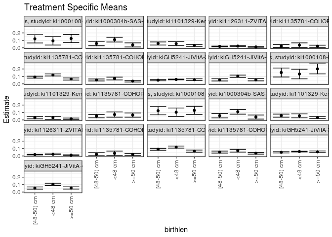

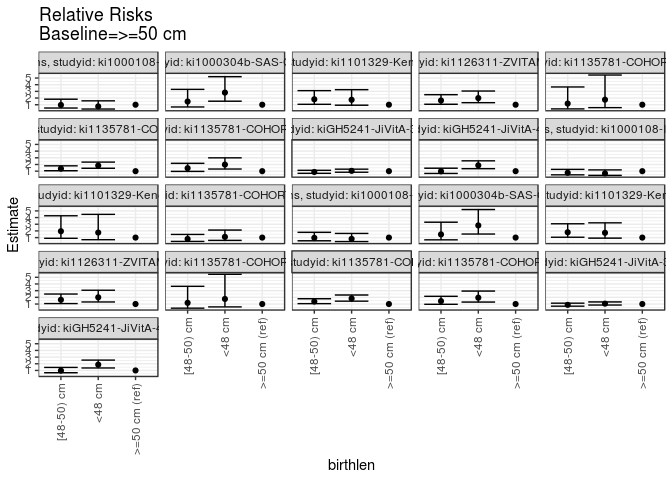

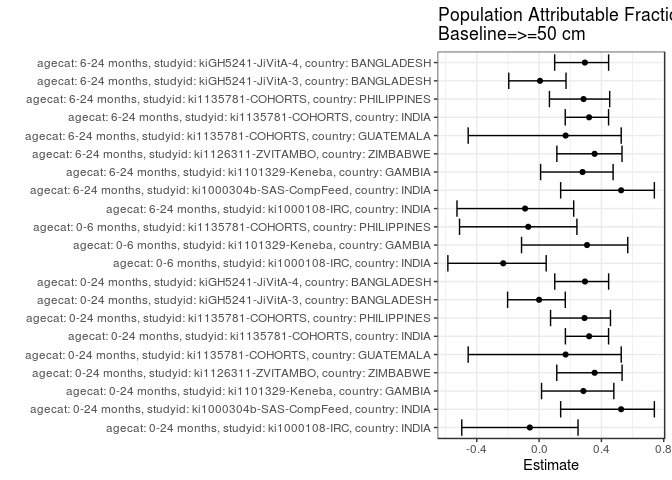

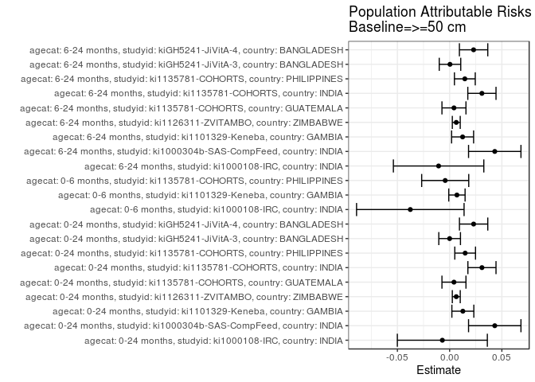

## Results Table

### Parameter: TSM

| agecat | studyid | country | intervention_level | baseline_level | estimate | ci_lower | ci_upper |
| --- | --- | --- | --- | --- | --- | --- | --- |
| 0-24 months | ki1000108-IRC | INDIA | >=50 cm | NA | 0.1246240 | 0.0697545 | 0.1794935 |
| 0-24 months | ki1000108-IRC | INDIA | <48 cm | NA | 0.0933969 | 0.0367392 | 0.1500547 |
| 0-24 months | ki1000108-IRC | INDIA | [48-50) cm | NA | 0.1201923 | 0.0646593 | 0.1757253 |
| 0-24 months | ki1000304b-SAS-CompFeed | INDIA | >=50 cm | NA | 0.0388350 | 0.0114714 | 0.0661985 |
| 0-24 months | ki1000304b-SAS-CompFeed | INDIA | <48 cm | NA | 0.1095506 | 0.0778598 | 0.1412413 |
| 0-24 months | ki1000304b-SAS-CompFeed | INDIA | [48-50) cm | NA | 0.0574713 | 0.0276190 | 0.0873235 |
| 0-24 months | ki1101329-Keneba | GAMBIA | >=50 cm | NA | 0.0318308 | 0.0191148 | 0.0445468 |
| 0-24 months | ki1101329-Keneba | GAMBIA | <48 cm | NA | 0.0554172 | 0.0286653 | 0.0821691 |
| 0-24 months | ki1101329-Keneba | GAMBIA | [48-50) cm | NA | 0.0578336 | 0.0369835 | 0.0786837 |
| 0-24 months | ki1126311-ZVITAMBO | ZIMBABWE | >=50 cm | NA | 0.0114871 | 0.0074046 | 0.0155695 |
| 0-24 months | ki1126311-ZVITAMBO | ZIMBABWE | <48 cm | NA | 0.0229044 | 0.0175531 | 0.0282557 |
| 0-24 months | ki1126311-ZVITAMBO | ZIMBABWE | [48-50) cm | NA | 0.0187957 | 0.0143645 | 0.0232269 |
| 0-24 months | ki1135781-COHORTS | GUATEMALA | >=50 cm | NA | 0.0201729 | 0.0053698 | 0.0349760 |
| 0-24 months | ki1135781-COHORTS | GUATEMALA | <48 cm | NA | 0.0354610 | 0.0049129 | 0.0660091 |
| 0-24 months | ki1135781-COHORTS | GUATEMALA | [48-50) cm | NA | 0.0236967 | 0.0031589 | 0.0442345 |
| 0-24 months | ki1135781-COHORTS | INDIA | >=50 cm | NA | 0.0653185 | 0.0509534 | 0.0796836 |
| 0-24 months | ki1135781-COHORTS | INDIA | <48 cm | NA | 0.1200249 | 0.1060681 | 0.1339816 |
| 0-24 months | ki1135781-COHORTS | INDIA | [48-50) cm | NA | 0.0903153 | 0.0774445 | 0.1031861 |
| 0-24 months | ki1135781-COHORTS | PHILIPPINES | >=50 cm | NA | 0.0361304 | 0.0247399 | 0.0475208 |
| 0-24 months | ki1135781-COHORTS | PHILIPPINES | <48 cm | NA | 0.0717404 | 0.0527710 | 0.0907097 |
| 0-24 months | ki1135781-COHORTS | PHILIPPINES | [48-50) cm | NA | 0.0523251 | 0.0389540 | 0.0656961 |
| 0-24 months | kiGH5241-JiVitA-3 | BANGLADESH | >=50 cm | NA | 0.0563556 | 0.0448044 | 0.0679069 |
| 0-24 months | kiGH5241-JiVitA-3 | BANGLADESH | <48 cm | NA | 0.0589134 | 0.0538376 | 0.0639892 |
| 0-24 months | kiGH5241-JiVitA-3 | BANGLADESH | [48-50) cm | NA | 0.0494289 | 0.0416540 | 0.0572038 |
| 0-24 months | kiGH5241-JiVitA-4 | BANGLADESH | >=50 cm | NA | 0.0550406 | 0.0401128 | 0.0699684 |
| 0-24 months | kiGH5241-JiVitA-4 | BANGLADESH | <48 cm | NA | 0.1029094 | 0.0878043 | 0.1180144 |
| 0-24 months | kiGH5241-JiVitA-4 | BANGLADESH | [48-50) cm | NA | 0.0535988 | 0.0387536 | 0.0684440 |
| 0-6 months | ki1000108-IRC | INDIA | >=50 cm | NA | 0.2012791 | 0.1341614 | 0.2683969 |
| 0-6 months | ki1000108-IRC | INDIA | <48 cm | NA | 0.1323170 | 0.0676560 | 0.1969780 |
| 0-6 months | ki1000108-IRC | INDIA | [48-50) cm | NA | 0.1524804 | 0.0921703 | 0.2127904 |
| 0-6 months | ki1101329-Keneba | GAMBIA | >=50 cm | NA | 0.0157143 | 0.0064979 | 0.0249307 |
| 0-6 months | ki1101329-Keneba | GAMBIA | <48 cm | NA | 0.0275591 | 0.0074195 | 0.0476986 |
| 0-6 months | ki1101329-Keneba | GAMBIA | [48-50) cm | NA | 0.0307018 | 0.0148627 | 0.0465408 |
| 0-6 months | ki1135781-COHORTS | PHILIPPINES | >=50 cm | NA | 0.0651968 | 0.0369827 | 0.0934108 |
| 0-6 months | ki1135781-COHORTS | PHILIPPINES | <48 cm | NA | 0.0722729 | 0.0370548 | 0.1074911 |
| 0-6 months | ki1135781-COHORTS | PHILIPPINES | [48-50) cm | NA | 0.0517258 | 0.0288282 | 0.0746235 |
| 6-24 months | ki1000108-IRC | INDIA | >=50 cm | NA | 0.1282099 | 0.0730756 | 0.1833441 |
| 6-24 months | ki1000108-IRC | INDIA | <48 cm | NA | 0.1035617 | 0.0469614 | 0.1601619 |
| 6-24 months | ki1000108-IRC | INDIA | [48-50) cm | NA | 0.1234998 | 0.0688750 | 0.1781245 |
| 6-24 months | ki1000304b-SAS-CompFeed | INDIA | >=50 cm | NA | 0.0388350 | 0.0114714 | 0.0661985 |
| 6-24 months | ki1000304b-SAS-CompFeed | INDIA | <48 cm | NA | 0.1095506 | 0.0778598 | 0.1412413 |
| 6-24 months | ki1000304b-SAS-CompFeed | INDIA | [48-50) cm | NA | 0.0574713 | 0.0276190 | 0.0873235 |
| 6-24 months | ki1101329-Keneba | GAMBIA | >=50 cm | NA | 0.0320729 | 0.0193198 | 0.0448260 |
| 6-24 months | ki1101329-Keneba | GAMBIA | <48 cm | NA | 0.0550458 | 0.0284591 | 0.0816326 |
| 6-24 months | ki1101329-Keneba | GAMBIA | [48-50) cm | NA | 0.0576299 | 0.0369180 | 0.0783417 |
| 6-24 months | ki1126311-ZVITAMBO | ZIMBABWE | >=50 cm | NA | 0.0114894 | 0.0074164 | 0.0155623 |
| 6-24 months | ki1126311-ZVITAMBO | ZIMBABWE | <48 cm | NA | 0.0230105 | 0.0176371 | 0.0283840 |
| 6-24 months | ki1126311-ZVITAMBO | ZIMBABWE | [48-50) cm | NA | 0.0187525 | 0.0143381 | 0.0231670 |
| 6-24 months | ki1135781-COHORTS | GUATEMALA | >=50 cm | NA | 0.0201729 | 0.0053698 | 0.0349760 |
| 6-24 months | ki1135781-COHORTS | GUATEMALA | <48 cm | NA | 0.0354610 | 0.0049129 | 0.0660091 |
| 6-24 months | ki1135781-COHORTS | GUATEMALA | [48-50) cm | NA | 0.0236967 | 0.0031589 | 0.0442345 |
| 6-24 months | ki1135781-COHORTS | INDIA | >=50 cm | NA | 0.0653582 | 0.0509344 | 0.0797819 |
| 6-24 months | ki1135781-COHORTS | INDIA | <48 cm | NA | 0.1197661 | 0.1058663 | 0.1336660 |
| 6-24 months | ki1135781-COHORTS | INDIA | [48-50) cm | NA | 0.0900977 | 0.0772459 | 0.1029495 |
| 6-24 months | ki1135781-COHORTS | PHILIPPINES | >=50 cm | NA | 0.0364366 | 0.0249753 | 0.0478979 |
| 6-24 months | ki1135781-COHORTS | PHILIPPINES | <48 cm | NA | 0.0710441 | 0.0522664 | 0.0898217 |
| 6-24 months | ki1135781-COHORTS | PHILIPPINES | [48-50) cm | NA | 0.0523565 | 0.0389758 | 0.0657371 |
| 6-24 months | kiGH5241-JiVitA-3 | BANGLADESH | >=50 cm | NA | 0.0560194 | 0.0445341 | 0.0675048 |
| 6-24 months | kiGH5241-JiVitA-3 | BANGLADESH | <48 cm | NA | 0.0591339 | 0.0540445 | 0.0642234 |
| 6-24 months | kiGH5241-JiVitA-3 | BANGLADESH | [48-50) cm | NA | 0.0491167 | 0.0412705 | 0.0569629 |
| 6-24 months | kiGH5241-JiVitA-4 | BANGLADESH | >=50 cm | NA | 0.0550695 | 0.0401258 | 0.0700131 |
| 6-24 months | kiGH5241-JiVitA-4 | BANGLADESH | <48 cm | NA | 0.1030442 | 0.0879367 | 0.1181517 |
| 6-24 months | kiGH5241-JiVitA-4 | BANGLADESH | [48-50) cm | NA | 0.0538665 | 0.0389984 | 0.0687346 |

### Parameter: E(Y)

| agecat | studyid | country | intervention_level | baseline_level | estimate | ci_lower | ci_upper |
| --- | --- | --- | --- | --- | --- | --- | --- |
| 0-24 months | ki1000108-IRC | INDIA | NA | NA | 0.1176471 | 0.0856708 | 0.1496233 |
| 0-24 months | ki1000304b-SAS-CompFeed | INDIA | NA | NA | 0.0820399 | 0.0573937 | 0.1066861 |
| 0-24 months | ki1101329-Keneba | GAMBIA | NA | NA | 0.0444887 | 0.0340722 | 0.0549052 |
| 0-24 months | ki1126311-ZVITAMBO | ZIMBABWE | NA | NA | 0.0178475 | 0.0151485 | 0.0205464 |
| 0-24 months | ki1135781-COHORTS | GUATEMALA | NA | NA | 0.0243205 | 0.0128927 | 0.0357482 |
| 0-24 months | ki1135781-COHORTS | INDIA | NA | NA | 0.0962597 | 0.0882935 | 0.1042259 |
| 0-24 months | ki1135781-COHORTS | PHILIPPINES | NA | NA | 0.0509986 | 0.0428544 | 0.0591428 |
| 0-24 months | kiGH5241-JiVitA-3 | BANGLADESH | NA | NA | 0.0563589 | 0.0522997 | 0.0604181 |
| 0-24 months | kiGH5241-JiVitA-4 | BANGLADESH | NA | NA | 0.0780045 | 0.0689447 | 0.0870643 |
| 0-6 months | ki1000108-IRC | INDIA | NA | NA | 0.1636364 | 0.1266348 | 0.2006379 |
| 0-6 months | ki1101329-Keneba | GAMBIA | NA | NA | 0.0226950 | 0.0149187 | 0.0304713 |
| 0-6 months | ki1135781-COHORTS | PHILIPPINES | NA | NA | 0.0609613 | 0.0448957 | 0.0770269 |
| 6-24 months | ki1000108-IRC | INDIA | NA | NA | 0.1176471 | 0.0856708 | 0.1496233 |
| 6-24 months | ki1000304b-SAS-CompFeed | INDIA | NA | NA | 0.0820399 | 0.0573937 | 0.1066861 |
| 6-24 months | ki1101329-Keneba | GAMBIA | NA | NA | 0.0444887 | 0.0340722 | 0.0549052 |
| 6-24 months | ki1126311-ZVITAMBO | ZIMBABWE | NA | NA | 0.0178475 | 0.0151485 | 0.0205464 |
| 6-24 months | ki1135781-COHORTS | GUATEMALA | NA | NA | 0.0243205 | 0.0128927 | 0.0357482 |
| 6-24 months | ki1135781-COHORTS | INDIA | NA | NA | 0.0962597 | 0.0882935 | 0.1042259 |
| 6-24 months | ki1135781-COHORTS | PHILIPPINES | NA | NA | 0.0509986 | 0.0428544 | 0.0591428 |
| 6-24 months | kiGH5241-JiVitA-3 | BANGLADESH | NA | NA | 0.0563589 | 0.0522997 | 0.0604181 |
| 6-24 months | kiGH5241-JiVitA-4 | BANGLADESH | NA | NA | 0.0780045 | 0.0689447 | 0.0870643 |

### Parameter: RR

| agecat | studyid | country | intervention_level | baseline_level | estimate | ci_lower | ci_upper |
| --- | --- | --- | --- | --- | --- | --- | --- |
| 0-24 months | ki1000108-IRC | INDIA | >=50 cm | >=50 cm | 1.0000000 | 1.0000000 | 1.000000 |
| 0-24 months | ki1000108-IRC | INDIA | <48 cm | >=50 cm | 0.7494299 | 0.3542923 | 1.585259 |
| 0-24 months | ki1000108-IRC | INDIA | [48-50) cm | >=50 cm | 0.9644395 | 0.5087777 | 1.828192 |
| 0-24 months | ki1000304b-SAS-CompFeed | INDIA | >=50 cm | >=50 cm | 1.0000000 | 1.0000000 | 1.000000 |
| 0-24 months | ki1000304b-SAS-CompFeed | INDIA | <48 cm | >=50 cm | 2.8209264 | 1.5294182 | 5.203041 |
| 0-24 months | ki1000304b-SAS-CompFeed | INDIA | [48-50) cm | >=50 cm | 1.4798847 | 0.6628767 | 3.303871 |
| 0-24 months | ki1101329-Keneba | GAMBIA | >=50 cm | >=50 cm | 1.0000000 | 1.0000000 | 1.000000 |
| 0-24 months | ki1101329-Keneba | GAMBIA | <48 cm | >=50 cm | 1.7409935 | 0.9307435 | 3.256599 |
| 0-24 months | ki1101329-Keneba | GAMBIA | [48-50) cm | >=50 cm | 1.8169073 | 1.0612306 | 3.110683 |
| 0-24 months | ki1126311-ZVITAMBO | ZIMBABWE | >=50 cm | >=50 cm | 1.0000000 | 1.0000000 | 1.000000 |
| 0-24 months | ki1126311-ZVITAMBO | ZIMBABWE | <48 cm | >=50 cm | 1.9939332 | 1.3031625 | 3.050863 |
| 0-24 months | ki1126311-ZVITAMBO | ZIMBABWE | [48-50) cm | >=50 cm | 1.6362512 | 1.0680539 | 2.506726 |
| 0-24 months | ki1135781-COHORTS | GUATEMALA | >=50 cm | >=50 cm | 1.0000000 | 1.0000000 | 1.000000 |
| 0-24 months | ki1135781-COHORTS | GUATEMALA | <48 cm | >=50 cm | 1.7578521 | 0.5669193 | 5.450589 |
| 0-24 months | ki1135781-COHORTS | GUATEMALA | [48-50) cm | >=50 cm | 1.1746784 | 0.3773324 | 3.656907 |
| 0-24 months | ki1135781-COHORTS | INDIA | >=50 cm | >=50 cm | 1.0000000 | 1.0000000 | 1.000000 |
| 0-24 months | ki1135781-COHORTS | INDIA | <48 cm | >=50 cm | 1.8375317 | 1.4328974 | 2.356430 |
| 0-24 months | ki1135781-COHORTS | INDIA | [48-50) cm | >=50 cm | 1.3826900 | 1.0639745 | 1.796877 |
| 0-24 months | ki1135781-COHORTS | PHILIPPINES | >=50 cm | >=50 cm | 1.0000000 | 1.0000000 | 1.000000 |
| 0-24 months | ki1135781-COHORTS | PHILIPPINES | <48 cm | >=50 cm | 1.9855958 | 1.3162818 | 2.995248 |
| 0-24 months | ki1135781-COHORTS | PHILIPPINES | [48-50) cm | >=50 cm | 1.4482284 | 0.9654420 | 2.172441 |
| 0-24 months | kiGH5241-JiVitA-3 | BANGLADESH | >=50 cm | >=50 cm | 1.0000000 | 1.0000000 | 1.000000 |
| 0-24 months | kiGH5241-JiVitA-3 | BANGLADESH | <48 cm | >=50 cm | 1.0453861 | 0.8408298 | 1.299707 |
| 0-24 months | kiGH5241-JiVitA-3 | BANGLADESH | [48-50) cm | >=50 cm | 0.8770888 | 0.6809447 | 1.129732 |
| 0-24 months | kiGH5241-JiVitA-4 | BANGLADESH | >=50 cm | >=50 cm | 1.0000000 | 1.0000000 | 1.000000 |
| 0-24 months | kiGH5241-JiVitA-4 | BANGLADESH | <48 cm | >=50 cm | 1.8696988 | 1.3730634 | 2.545967 |
| 0-24 months | kiGH5241-JiVitA-4 | BANGLADESH | [48-50) cm | >=50 cm | 0.9738047 | 0.6567216 | 1.443984 |
| 0-6 months | ki1000108-IRC | INDIA | >=50 cm | >=50 cm | 1.0000000 | 1.0000000 | 1.000000 |
| 0-6 months | ki1000108-IRC | INDIA | <48 cm | >=50 cm | 0.6573806 | 0.3635452 | 1.188708 |
| 0-6 months | ki1000108-IRC | INDIA | [48-50) cm | >=50 cm | 0.7575567 | 0.4512455 | 1.271796 |
| 0-6 months | ki1101329-Keneba | GAMBIA | >=50 cm | >=50 cm | 1.0000000 | 1.0000000 | 1.000000 |
| 0-6 months | ki1101329-Keneba | GAMBIA | <48 cm | >=50 cm | 1.7537581 | 0.6871083 | 4.476248 |
| 0-6 months | ki1101329-Keneba | GAMBIA | [48-50) cm | >=50 cm | 1.9537480 | 0.8946155 | 4.266784 |
| 0-6 months | ki1135781-COHORTS | PHILIPPINES | >=50 cm | >=50 cm | 1.0000000 | 1.0000000 | 1.000000 |
| 0-6 months | ki1135781-COHORTS | PHILIPPINES | <48 cm | >=50 cm | 1.1085353 | 0.5777691 | 2.126889 |
| 0-6 months | ki1135781-COHORTS | PHILIPPINES | [48-50) cm | >=50 cm | 0.7933801 | 0.4271310 | 1.473675 |
| 6-24 months | ki1000108-IRC | INDIA | >=50 cm | >=50 cm | 1.0000000 | 1.0000000 | 1.000000 |
| 6-24 months | ki1000108-IRC | INDIA | <48 cm | >=50 cm | 0.8077513 | 0.4028060 | 1.619792 |
| 6-24 months | ki1000108-IRC | INDIA | [48-50) cm | >=50 cm | 0.9632626 | 0.5191575 | 1.787271 |
| 6-24 months | ki1000304b-SAS-CompFeed | INDIA | >=50 cm | >=50 cm | 1.0000000 | 1.0000000 | 1.000000 |
| 6-24 months | ki1000304b-SAS-CompFeed | INDIA | <48 cm | >=50 cm | 2.8209264 | 1.5294182 | 5.203041 |
| 6-24 months | ki1000304b-SAS-CompFeed | INDIA | [48-50) cm | >=50 cm | 1.4798847 | 0.6628767 | 3.303871 |
| 6-24 months | ki1101329-Keneba | GAMBIA | >=50 cm | >=50 cm | 1.0000000 | 1.0000000 | 1.000000 |
| 6-24 months | ki1101329-Keneba | GAMBIA | <48 cm | >=50 cm | 1.7162717 | 0.9181476 | 3.208186 |
| 6-24 months | ki1101329-Keneba | GAMBIA | [48-50) cm | >=50 cm | 1.7968392 | 1.0517710 | 3.069709 |
| 6-24 months | ki1126311-ZVITAMBO | ZIMBABWE | >=50 cm | >=50 cm | 1.0000000 | 1.0000000 | 1.000000 |
| 6-24 months | ki1126311-ZVITAMBO | ZIMBABWE | <48 cm | >=50 cm | 2.0027665 | 1.3100475 | 3.061777 |
| 6-24 months | ki1126311-ZVITAMBO | ZIMBABWE | [48-50) cm | >=50 cm | 1.6321631 | 1.0664980 | 2.497854 |
| 6-24 months | ki1135781-COHORTS | GUATEMALA | >=50 cm | >=50 cm | 1.0000000 | 1.0000000 | 1.000000 |
| 6-24 months | ki1135781-COHORTS | GUATEMALA | <48 cm | >=50 cm | 1.7578521 | 0.5669193 | 5.450589 |
| 6-24 months | ki1135781-COHORTS | GUATEMALA | [48-50) cm | >=50 cm | 1.1746784 | 0.3773324 | 3.656907 |
| 6-24 months | ki1135781-COHORTS | INDIA | >=50 cm | >=50 cm | 1.0000000 | 1.0000000 | 1.000000 |
| 6-24 months | ki1135781-COHORTS | INDIA | <48 cm | >=50 cm | 1.8324581 | 1.4281993 | 2.351144 |
| 6-24 months | ki1135781-COHORTS | INDIA | [48-50) cm | >=50 cm | 1.3785223 | 1.0600200 | 1.792725 |
| 6-24 months | ki1135781-COHORTS | PHILIPPINES | >=50 cm | >=50 cm | 1.0000000 | 1.0000000 | 1.000000 |
| 6-24 months | ki1135781-COHORTS | PHILIPPINES | <48 cm | >=50 cm | 1.9497989 | 1.2934485 | 2.939209 |
| 6-24 months | ki1135781-COHORTS | PHILIPPINES | [48-50) cm | >=50 cm | 1.4369193 | 0.9584800 | 2.154179 |
| 6-24 months | kiGH5241-JiVitA-3 | BANGLADESH | >=50 cm | >=50 cm | 1.0000000 | 1.0000000 | 1.000000 |
| 6-24 months | kiGH5241-JiVitA-3 | BANGLADESH | <48 cm | >=50 cm | 1.0555961 | 0.8493284 | 1.311958 |
| 6-24 months | kiGH5241-JiVitA-3 | BANGLADESH | [48-50) cm | >=50 cm | 0.8767796 | 0.6802339 | 1.130115 |
| 6-24 months | kiGH5241-JiVitA-4 | BANGLADESH | >=50 cm | >=50 cm | 1.0000000 | 1.0000000 | 1.000000 |
| 6-24 months | kiGH5241-JiVitA-4 | BANGLADESH | <48 cm | >=50 cm | 1.8711681 | 1.3739869 | 2.548256 |
| 6-24 months | kiGH5241-JiVitA-4 | BANGLADESH | [48-50) cm | >=50 cm | 0.9781557 | 0.6601346 | 1.449384 |

### Parameter: PAR

| agecat | studyid | country | intervention_level | baseline_level | estimate | ci_lower | ci_upper |
| --- | --- | --- | --- | --- | --- | --- | --- |
| 0-24 months | ki1000108-IRC | INDIA | >=50 cm | NA | -0.0069769 | -0.0500608 | 0.0361069 |
| 0-24 months | ki1000304b-SAS-CompFeed | INDIA | >=50 cm | NA | 0.0432050 | 0.0181178 | 0.0682921 |
| 0-24 months | ki1101329-Keneba | GAMBIA | >=50 cm | NA | 0.0126579 | 0.0021478 | 0.0231680 |
| 0-24 months | ki1126311-ZVITAMBO | ZIMBABWE | >=50 cm | NA | 0.0063604 | 0.0025687 | 0.0101522 |
| 0-24 months | ki1135781-COHORTS | GUATEMALA | >=50 cm | NA | 0.0041475 | -0.0073486 | 0.0156437 |
| 0-24 months | ki1135781-COHORTS | INDIA | >=50 cm | NA | 0.0309412 | 0.0174827 | 0.0443997 |
| 0-24 months | ki1135781-COHORTS | PHILIPPINES | >=50 cm | NA | 0.0148682 | 0.0049477 | 0.0247887 |
| 0-24 months | kiGH5241-JiVitA-3 | BANGLADESH | >=50 cm | NA | 0.0000033 | -0.0103695 | 0.0103761 |
| 0-24 months | kiGH5241-JiVitA-4 | BANGLADESH | >=50 cm | NA | 0.0229639 | 0.0094067 | 0.0365212 |
| 0-6 months | ki1000108-IRC | INDIA | >=50 cm | NA | -0.0376428 | -0.0891102 | 0.0138247 |
| 0-6 months | ki1101329-Keneba | GAMBIA | >=50 cm | NA | 0.0069807 | -0.0008342 | 0.0147957 |
| 0-6 months | ki1135781-COHORTS | PHILIPPINES | >=50 cm | NA | -0.0042355 | -0.0267653 | 0.0182944 |
| 6-24 months | ki1000108-IRC | INDIA | >=50 cm | NA | -0.0105628 | -0.0538521 | 0.0327265 |
| 6-24 months | ki1000304b-SAS-CompFeed | INDIA | >=50 cm | NA | 0.0432050 | 0.0181178 | 0.0682921 |
| 6-24 months | ki1101329-Keneba | GAMBIA | >=50 cm | NA | 0.0124158 | 0.0018813 | 0.0229503 |
| 6-24 months | ki1126311-ZVITAMBO | ZIMBABWE | >=50 cm | NA | 0.0063581 | 0.0025742 | 0.0101421 |
| 6-24 months | ki1135781-COHORTS | GUATEMALA | >=50 cm | NA | 0.0041475 | -0.0073486 | 0.0156437 |
| 6-24 months | ki1135781-COHORTS | INDIA | >=50 cm | NA | 0.0309016 | 0.0173982 | 0.0444049 |
| 6-24 months | ki1135781-COHORTS | PHILIPPINES | >=50 cm | NA | 0.0145620 | 0.0045942 | 0.0245297 |
| 6-24 months | kiGH5241-JiVitA-3 | BANGLADESH | >=50 cm | NA | 0.0003395 | -0.0099548 | 0.0106338 |
| 6-24 months | kiGH5241-JiVitA-4 | BANGLADESH | >=50 cm | NA | 0.0229351 | 0.0093543 | 0.0365159 |

### Parameter: PAF

| agecat | studyid | country | intervention_level | baseline_level | estimate | ci_lower | ci_upper |
| --- | --- | --- | --- | --- | --- | --- | --- |
| 0-24 months | ki1000108-IRC | INDIA | >=50 cm | NA | -0.0593040 | -0.4961999 | 0.2500167 |
| 0-24 months | ki1000304b-SAS-CompFeed | INDIA | >=50 cm | NA | 0.5266333 | 0.1384809 | 0.7399060 |
| 0-24 months | ki1101329-Keneba | GAMBIA | >=50 cm | NA | 0.2845200 | 0.0159101 | 0.4798122 |
| 0-24 months | ki1126311-ZVITAMBO | ZIMBABWE | >=50 cm | NA | 0.3563767 | 0.1135384 | 0.5326917 |
| 0-24 months | ki1135781-COHORTS | GUATEMALA | >=50 cm | NA | 0.1705374 | -0.4549860 | 0.5271375 |
| 0-24 months | ki1135781-COHORTS | INDIA | >=50 cm | NA | 0.3214346 | 0.1689099 | 0.4459674 |
| 0-24 months | ki1135781-COHORTS | PHILIPPINES | >=50 cm | NA | 0.2915411 | 0.0736790 | 0.4581641 |
| 0-24 months | kiGH5241-JiVitA-3 | BANGLADESH | >=50 cm | NA | 0.0000587 | -0.2020171 | 0.1681628 |
| 0-24 months | kiGH5241-JiVitA-4 | BANGLADESH | >=50 cm | NA | 0.2943922 | 0.1006955 | 0.4463696 |
| 0-6 months | ki1000108-IRC | INDIA | >=50 cm | NA | -0.2300392 | -0.5853940 | 0.0456654 |
| 0-6 months | ki1101329-Keneba | GAMBIA | >=50 cm | NA | 0.3075893 | -0.1125539 | 0.5690702 |
| 0-6 months | ki1135781-COHORTS | PHILIPPINES | >=50 cm | NA | -0.0694781 | -0.5105057 | 0.2427812 |
| 6-24 months | ki1000108-IRC | INDIA | >=50 cm | NA | -0.0897839 | -0.5268496 | 0.2221702 |
| 6-24 months | ki1000304b-SAS-CompFeed | INDIA | >=50 cm | NA | 0.5266333 | 0.1384809 | 0.7399060 |
| 6-24 months | ki1101329-Keneba | GAMBIA | >=50 cm | NA | 0.2790775 | 0.0098776 | 0.4750859 |
| 6-24 months | ki1126311-ZVITAMBO | ZIMBABWE | >=50 cm | NA | 0.3562473 | 0.1141066 | 0.5322038 |
| 6-24 months | ki1135781-COHORTS | GUATEMALA | >=50 cm | NA | 0.1705374 | -0.4549860 | 0.5271375 |
| 6-24 months | ki1135781-COHORTS | INDIA | >=50 cm | NA | 0.3210227 | 0.1678550 | 0.4459977 |
| 6-24 months | ki1135781-COHORTS | PHILIPPINES | >=50 cm | NA | 0.2855368 | 0.0664642 | 0.4531997 |
| 6-24 months | kiGH5241-JiVitA-3 | BANGLADESH | >=50 cm | NA | 0.0060239 | -0.1945512 | 0.1729207 |
| 6-24 months | kiGH5241-JiVitA-4 | BANGLADESH | >=50 cm | NA | 0.2940223 | 0.0999795 | 0.4462298 |